# Weight Lifting Prediction Assignment

Abril Susana

2025-02-20

# Introduction

In this project, we aim to predict the manner in which individuals perform a weight lifting exercise using data from accelerometers placed on different body parts. The target variable is “classe”, which represents the manner in which the exercise was performed. The dataset includes accelerometer readings from devices on the belt, forearm, arm, and dumbbell of 6 participants.

The goal is to predict the “classe” variable, which represents how the exercise is performed, based on sensor data from the accelerometers. First, let’s load the necessary libraries and the datasets.

```r
library(caret)
```

```r
library(rpart)
library(rpart.plot)
library(rattle)
library(randomForest)
library(gbm)
# Load training and test data
train_url <- "https://d396qusza40orc.cloudfront.net/predmachlearn/pml-training.csv"
test_url <- "https://d396qusza40orc.cloudfront.net/predmachlearn/pml-testing.csv"

training_set <- read.csv(train_url, na.strings = c("NA","#DIV/0!", ""))
testing_set <- read.csv(test_url, na.strings = c("NA","#DIV/0!", ""))
```

# Data Cleaning

The dataset has a large number of columns, and many of them contain missing values or irrelevant information, such as user identification. To ensure we use only relevant and reliable data for training our model, we will:

Remove columns with a high percentage of missing values. Keep only the numeric columns that are relevant for predicting the target variable. Clean out non-numeric variables, such as user identification data.

```r
nearZeroVar <- nearZeroVar(training_set)
train_data <- training_set[,-nearZeroVar]
test_data <- testing_set[,-nearZeroVar]
str(test_data)
```

```
## 'data.frame':    20 obs. of  124 variables:
##  $ X                       : int  1 2 3 4 5 6 7 8 9 10 ...
##  $ user_name               : chr  "pedro" "jeremy" "jeremy" "adelmo" ...
##  $ raw_timestamp_part_1    : int  1323095002 1322673067 1322673075 1322832789 1322489635 1322673149 1322673128 1322673076 1323084240 1322837822 ...
##  $ raw_timestamp_part_2    : int  868349 778725 342967 560311 814776 510661 766645 54671 916313 384285 ...
##  $ cvtd_timestamp          : chr  "05/12/2011 14:23" "30/11/2011 17:11" "30/11/2011 17:11" "02/12/2011 13:33" ...
##  $ num_window              : int  74 431 439 194 235 504 485 440 323 664 ...
##  $ roll_belt               : num  123 1.02 0.87 125 1.35 -5.92 1.2 0.43 0.93 114 ...
##  $ pitch_belt              : num  27 4.87 1.82 -41.6 3.33 1.59 4.44 4.15 6.72 22.4 ...
##  $ yaw_belt                : num  -4.75 -88.9 -88.5 162 -88.6 -87.7 -87.3 -88.5 -93.7 -13.1 ...
##  $ total_accel_belt        : int  20 4 5 17 3 4 4 4 4 18 ...
##  $ kurtosis_roll_belt      : logi  NA NA NA NA NA NA ...
##  $ kurtosis_picth_belt     : logi  NA NA NA NA NA NA ...
##  $ skewness_roll_belt      : logi  NA NA NA NA NA NA ...
##  $ skewness_roll_belt.1    : logi  NA NA NA NA NA NA ...
```

[output cut: 86 more lines]

```r
NaCols <- sapply(train_data, function(x) mean(is.na(x))) > 0.95
train_data <- train_data[,NaCols == FALSE]
test_data <- test_data[,NaCols == FALSE]
str(test_data)
```

```
## 'data.frame':    20 obs. of  59 variables:
##  $ X                   : int  1 2 3 4 5 6 7 8 9 10 ...
##  $ user_name           : chr  "pedro" "jeremy" "jeremy" "adelmo" ...
##  $ raw_timestamp_part_1: int  1323095002 1322673067 1322673075 1322832789 1322489635 1322673149 1322673128 1322673076 1323084240 1322837822 ...
##  $ raw_timestamp_part_2: int  868349 778725 342967 560311 814776 510661 766645 54671 916313 384285 ...
##  $ cvtd_timestamp      : chr  "05/12/2011 14:23" "30/11/2011 17:11" "30/11/2011 17:11" "02/12/2011 13:33" ...
##  $ num_window          : int  74 431 439 194 235 504 485 440 323 664 ...
##  $ roll_belt           : num  123 1.02 0.87 125 1.35 -5.92 1.2 0.43 0.93 114 ...
##  $ pitch_belt          : num  27 4.87 1.82 -41.6 3.33 1.59 4.44 4.15 6.72 22.4 ...
##  $ yaw_belt            : num  -4.75 -88.9 -88.5 162 -88.6 -87.7 -87.3 -88.5 -93.7 -13.1 ...
##  $ total_accel_belt    : int  20 4 5 17 3 4 4 4 4 18 ...
##  $ gyros_belt_x        : num  -0.5 -0.06 0.05 0.11 0.03 0.1 -0.06 -0.18 0.1 0.14 ...
##  $ gyros_belt_y        : num  -0.02 -0.02 0.02 0.11 0.02 0.05 0 -0.02 0 0.11 ...
##  $ gyros_belt_z        : num  -0.46 -0.07 0.03 -0.16 0 -0.13 0 -0.03 -0.02 -0.16 ...
##  $ accel_belt_x        : int  -38 -13 1 46 -8 -11 -14 -10 -15 -25 ...
```

[output cut: 45 more lines]

```r
# Removing the first 6 variables that are non-numeric

train_data <- train_data[,7:59]
test_data <- test_data[,7:59]
str(test_data)
```

```
## 'data.frame':    20 obs. of  53 variables:
##  $ roll_belt           : num  123 1.02 0.87 125 1.35 -5.92 1.2 0.43 0.93 114 ...
##  $ pitch_belt          : num  27 4.87 1.82 -41.6 3.33 1.59 4.44 4.15 6.72 22.4 ...
##  $ yaw_belt            : num  -4.75 -88.9 -88.5 162 -88.6 -87.7 -87.3 -88.5 -93.7 -13.1 ...
##  $ total_accel_belt    : int  20 4 5 17 3 4 4 4 4 18 ...
##  $ gyros_belt_x        : num  -0.5 -0.06 0.05 0.11 0.03 0.1 -0.06 -0.18 0.1 0.14 ...
##  $ gyros_belt_y        : num  -0.02 -0.02 0.02 0.11 0.02 0.05 0 -0.02 0 0.11 ...
##  $ gyros_belt_z        : num  -0.46 -0.07 0.03 -0.16 0 -0.13 0 -0.03 -0.02 -0.16 ...
##  $ accel_belt_x        : int  -38 -13 1 46 -8 -11 -14 -10 -15 -25 ...
##  $ accel_belt_y        : int  69 11 -1 45 4 -16 2 -2 1 63 ...
##  $ accel_belt_z        : int  -179 39 49 -156 27 38 35 42 32 -158 ...
##  $ magnet_belt_x       : int  -13 43 29 169 33 31 50 39 -6 10 ...
##  $ magnet_belt_y       : int  581 636 631 608 566 638 622 635 600 601 ...
##  $ magnet_belt_z       : int  -382 -309 -312 -304 -418 -291 -315 -305 -302 -330 ...
##  $ roll_arm            : num  40.7 0 0 -109 76.1 0 0 0 -137 -82.4 ...
```

[output cut: 39 more lines]

# Validation set

To evaluate the model’s performance, we will split the data into a training set and a validation set. The training set is used to build the model, and the validation set is used to test how well the model generalizes to unseen data.

```r
inTrain<- createDataPartition(train_data$classe, p=0.6, list=FALSE)
training<- train_data[inTrain,]
validating<- train_data[-inTrain,]
dim(training)
```

```
## [1] 11776    53
```

```r
dim(validating)
```

```
## [1] 7846   53
```

# Decision Tree Model

A decision tree is a flowchart-like tree structure where each internal node represents a feature, and each leaf node represents a class label. We will build a decision tree model to predict the “classe” variable using the training data. We will also visualize the tree.

[figure not shown]

```r
DT_modelfit<- train(classe ~. , data=training, method= "rpart")
fancyRpartPlot(DT_modelfit$finalModel)
```

```r
DT_prediction <- predict(DT_modelfit, validating)
confusionMatrix(as.factor(DT_prediction), as.factor(validating$classe))
```

```
## Confusion Matrix and Statistics
##
##           Reference
## Prediction    A    B    C    D    E
##          A 1323  228   34   59   10
##          B  245  866   66  198  343
##          C  491  353 1098  681  359
##          D  168   71  170  348   78
##          E    5    0    0    0  652
##
## Overall Statistics
##
##                Accuracy : 0.5464
##                  95% CI : (0.5353, 0.5575)
##     No Information Rate : 0.2845
##     P-Value [Acc > NIR] : < 2.2e-16
##
##                   Kappa : 0.432
##
##  Mcnemar's Test P-Value : < 2.2e-16
##
## Statistics by Class:
##
##                      Class: A Class: B Class: C Class: D Class: E
## Sensitivity            0.5927   0.5705   0.8026  0.27061  0.45215
## Specificity            0.9410   0.8654   0.7092  0.92576  0.99922
## Pos Pred Value         0.7999   0.5041   0.3682  0.41677  0.99239
## Neg Pred Value         0.8532   0.8936   0.9445  0.86621  0.89011
## Prevalence             0.2845   0.1935   0.1744  0.16391  0.18379
## Detection Rate         0.1686   0.1104   0.1399  0.04435  0.08310
## Detection Prevalence   0.2108   0.2190   0.3801  0.10642  0.08374
## Balanced Accuracy      0.7669   0.7179   0.7559  0.59818  0.72568
```

The decision tree model’s performance is evaluated using a confusion matrix, which helps us assess the model’s accuracy, precision, recall, and other important metrics.

# Random Forest Model

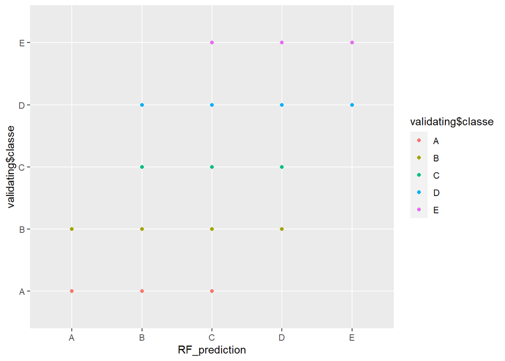

```r
RF_modelfit <- train(classe ~ ., data = training, method = "rf", ntree = 100)
RF_prediction<- predict(RF_modelfit, validating)
qplot(RF_prediction,validating$classe, colour=validating$classe)
```

The results of the random forest model will be visualized using a scatter plot that shows the relationship between predicted and actual classes in the validation set.

# Gradient Boosting Model

Gradient boosting is another powerful ensemble technique that combines the predictions of several base learners (typically decision trees) to improve accuracy. We will build and evaluate a gradient boosting model for this task.

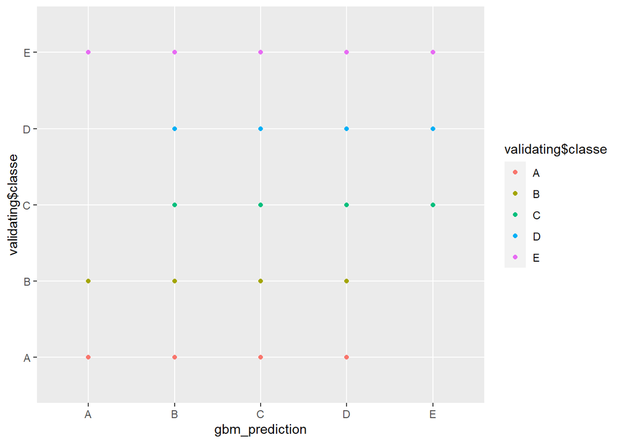

```r
gbm_modelfit<- train(classe~., data=training, method="gbm", verbose= FALSE)
gbm_prediction<- predict(gbm_modelfit, validating)
qplot(gbm_prediction,validating$classe, colour=validating$classe)
```

```r
gbm_confusionMatrix<-confusionMatrix(as.factor(gbm_prediction), as.factor(validating$classe))
gbm_confusionMatrix
```

```
## Confusion Matrix and Statistics
##
##           Reference
## Prediction    A    B    C    D    E
##          A 2187   45    0    0    3
##          B   32 1438   52    3   16
##          C   11   33 1293   39   19
##          D    2    2   20 1234   27
##          E    0    0    3   10 1377
##
## Overall Statistics
##
##                Accuracy : 0.9596
##                  95% CI : (0.955, 0.9638)
##     No Information Rate : 0.2845
##     P-Value [Acc > NIR] : < 2.2e-16
##
##                   Kappa : 0.9489
##
##  Mcnemar's Test P-Value : 5.744e-10
##
## Statistics by Class:
##
##                      Class: A Class: B Class: C Class: D Class: E
## Sensitivity            0.9798   0.9473   0.9452   0.9596   0.9549
## Specificity            0.9914   0.9837   0.9843   0.9922   0.9980
## Pos Pred Value         0.9785   0.9332   0.9269   0.9603   0.9906
## Neg Pred Value         0.9920   0.9873   0.9884   0.9921   0.9899
## Prevalence             0.2845   0.1935   0.1744   0.1639   0.1838
## Detection Rate         0.2787   0.1833   0.1648   0.1573   0.1755
## Detection Prevalence   0.2849   0.1964   0.1778   0.1638   0.1772
## Balanced Accuracy      0.9856   0.9655   0.9647   0.9759   0.9764
```

The performance of the gradient boosting model is assessed by a confusion matrix, providing a detailed evaluation of the model’s accuracy.

# Conclusion

```r
test_prediction<- predict(RF_modelfit, test_data)
test_prediction
```

```
##  [1] B A B A A E D B A A B C B A E E A B B B
## Levels: A B C D E
```

The output shows the predicted exercise manner (“classe”) for the 20 test cases.